# What do supporters of Trump and Biden think about Trump as the president in the last four years?

# Information about the data

As the election 2020 is closer, the competition between Trump and Biden is becoming a hot topic in this special year. People all over the world pay attention to the results. This year many new issues happened, such as COVID-19, Black lives matters protest. We are conducting the data analysis using the **2020 Exploratory Testing Survey** dataset from ANES(American National Election Studies). Because the survey contains information on the novel issues arising in the election year. The pilot study was conducted via the internet between Apr 10 and Apr 18. The survey collected 3,080 sample data. See more detail [here](https://electionstudies.org/data-center/2020-exploratory-testing-survey/).

From analyzing the data, we draw some interesting conclusions. Let’s find out!

# How many people have changed their minds?

As we see the plot below, which shows us who people voted for in 2016 and will vote this year, we can draw a conclusion that most of the people keep a stand. Especially, Trump remainS 87.86% of his supporter to support him this year again, while Biden remainS 87.48%, which is less, of Clinton’s supporter to support him this year.

However, some people have changed their minds. From the plot we can see, more people change from Trump’s camp to Biden’s than from Biden’s group to Trump’s. But some of the Biden’s camp leave to someone else’s camp. Worth mentioning, Biden attracts more people who quit voting in 2016 to his camp this year than Trump does.

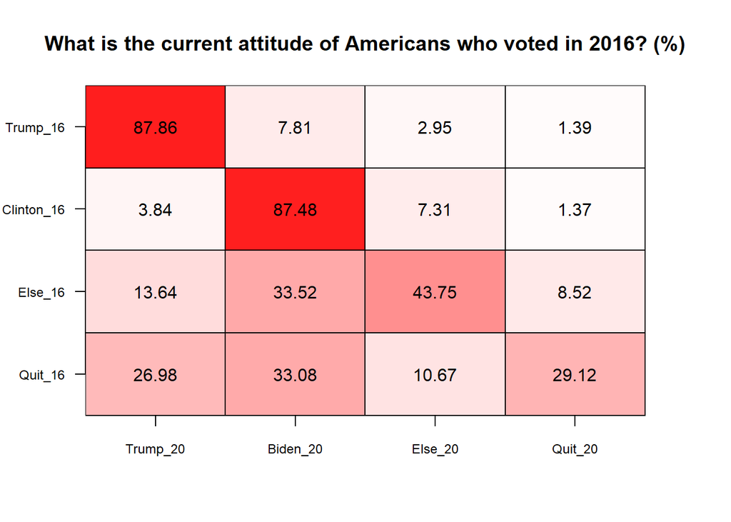

```r
vote_freq<-as.data.frame(table(pilot_data[,c('vote16','vote20jb')])) # gain the frequency of groups of people.
total16<-as.data.frame(table(pilot_data[,c('vote16')])) # count the total number of people vote in different categories.
vote_heat<-as.data.frame(matrix(c(vote_freq[vote_freq$vote20jb==1,'Freq'],
             vote_freq[vote_freq$vote20jb==2,'Freq'],
             vote_freq[vote_freq$vote20jb==3,'Freq'],
             vote_freq[vote_freq$vote20jb==4,'Freq'],
             vote_freq[vote_freq$vote20jb==9,'Freq']),5,5))[1:4,1:4] # calculate the
vote_heat[1,]<-vote_heat[1,]/total16[1,2]*100
vote_heat[2,]<-vote_heat[2,]/total16[2,2]*100
vote_heat[3,]<-vote_heat[3,]/total16[3,2]*100
vote_heat[4,]<-vote_heat[4,]/total16[4,2]*100
# calculate the percentage of people based on their votes in 2016 and 2020.
colnames(vote_heat)<-c('Trump_20','Biden_20','Else_20','Quit_20')
rownames(vote_heat)<-c('Trump_16','Clinton_16','Else_16','Quit_16')
par(mar=c(5.1,4.1,4.1,4.1))
plot(as.matrix(vote_heat),col = colorRampPalette(c("white","red")),breaks=1000,fmt.cell='%.2f',text.cell = list(cex=1),key=NULL,cex.axis=.75,axis.row = list(las=1),ylab='',xlab='',main='What is the current attitude of Americans who voted in 2016? (%)')
```

```r
#plot the heatmap.
```

# So how well did Trump do his job as the president in the last four years?

We would like to figure out ‘What do Americans think about Trump’s job as the president in the last four years?’.

So, we split the data into two parts, people who vote Trump this year and people who vote Biden this year. Let’s see how do they rate Trump’s work in various fields.

Surely, Biden’s supporters tend to dislike Trump’s work. But we still find something interesting by comparing the opinions of the two groups.

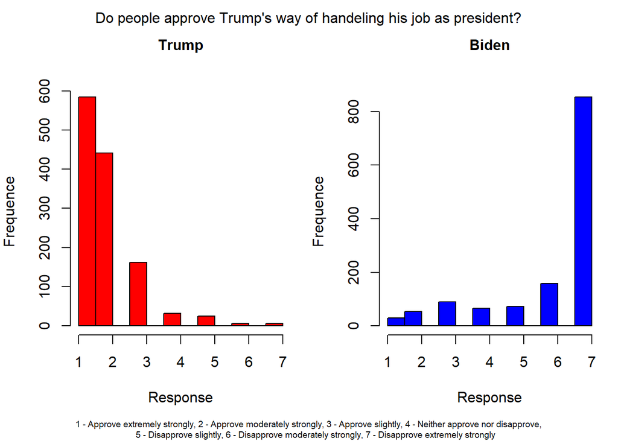

```r
par(mfrow=c(1,2),mar=c(6,4,5,1))
hist(trump20$apppres7[trump20$apppres7<=7],xlab='Response',ylab='Frequence',main = 'Trump',cex.main=1,col="red")
hist(biden20$apppres7[biden20$apppres7<=7],xlab='Response',ylab='Frequence',main = 'Biden',cex.main=1,col="blue")
mtext("Do people approve Trump's way of handeling his job as president?", outer=TRUE,cex = 1,line=-1.5)
mtext("1 - Approve extremely strongly, 2 - Approve moderately strongly, 3 - Approve slightly, 4 - Neither approve nor disapprove,
      5 - Disapprove slightly, 6 - Disapprove moderately strongly, 7 - Disapprove extremely strongly", outer=TRUE,cex = .6,line=-25)
```

What about people’s opinions on Trump’s job about **International Relations**, **Immigration**, **Economy** and **Health Care & Covid-19**? The survey asked people to express their opinions and we can see the difference as the plot below.

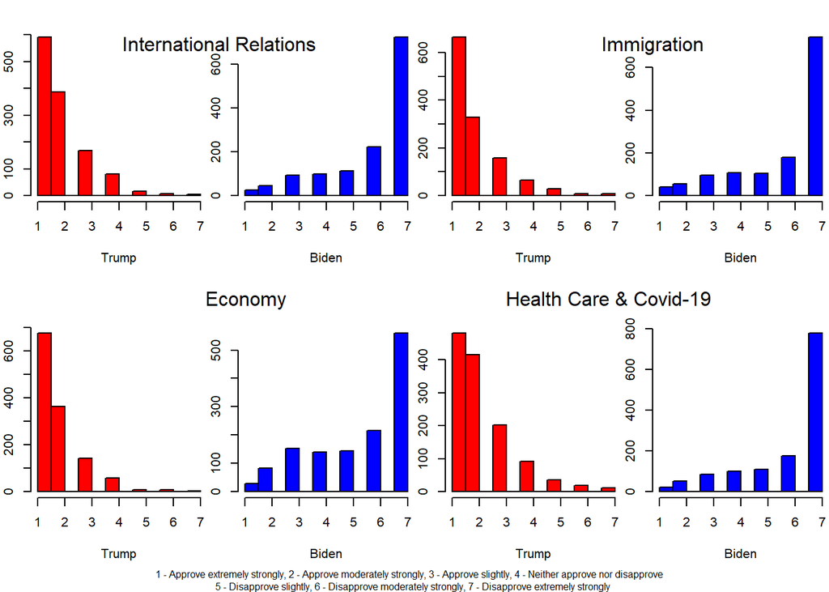

```r
par(mfrow=c(2,4),mar=c(6,2,2,0))
hist(trump20$frnpres7[trump20$frnpres7<=7],xlab='Trump',ylab='',main = '',col="red")
hist(biden20$frnpres7[biden20$frnpres7<=7],xlab='Biden',ylab='',main = '',col="blue")

hist(trump20$immpres7[trump20$immpres7<=7],xlab='Trump',ylab='',main = '',col="red")
hist(biden20$immpres7[biden20$immpres7<=7],xlab='Biden',ylab='',main = '',col="blue")

hist(trump20$econpres7[trump20$econpres7<=7],xlab='Trump',ylab='',main = '',col="red")
hist(biden20$econpres7[biden20$econpres7<=7],xlab='Biden',ylab='',main = '',col="blue")

hist(ifelse(trump20$covidpres7<=7,trump20$covidpres7,trump20$healthcarepres7),xlab='Trump',ylab='',main = '',col="red")
hist(ifelse(biden20$covidpres7<=7,biden20$covidpres7,biden20$healthcarepres7),xlab='Biden',ylab='',main = '',col="blue")

mtext("1 - Approve extremely strongly, 2 - Approve moderately strongly, 3 - Approve slightly, 4 - Neither approve nor disapprove", cex = .5,line=-16.2,adj = +1.5)
mtext("5 - Disapprove slightly, 6 - Disapprove moderately strongly, 7 - Disapprove extremely strongly", cex = .5,adj=+2,line=-17)
mtext("International Relations", cex = 1,line=17.5,adj=+30)
mtext("Immigration", cex = 1,line=17.5,adj=-.7)
mtext("Economy", cex = 1,line=1.2,adj=-4.7)
mtext("Health Care & Covid-19", cex = 1,line=1.2,adj=+5)
```

From the plot we have two interesting findings: 1. Compared to **International Relations**, **Immigration** and **Health Care &COVID-19**, Biden’s supporters are more likely to approve Trump’s job in **Economy**. 2. Compared to **International Relations**, **Immigration**, and **Economy**, Trump’s supporters are more likely to disagree with Trump’s policy about **Health Care & COVID-19**.

So, the findings show that some of Biden’s supporters approve Trump’s policy in **Economy** and some of Trump’s supporters dislike his policy in **Health Care & COVID-19**. That’s interesting. Why? Let’s find out.

## Economy

### Do people think the economy is getting better or worse?

In the survey, people were asked that “Compare to one year ago, whether you think that the nation’s economy is now better, about the same, or worse?” Here are different groups of people’s responses.

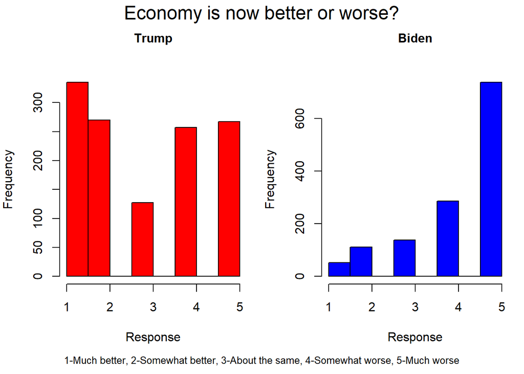

```r
par(mfrow=c(1,2),mar=c(6,4,5,1))
hist(trump20$econnow[trump20$econnow<=5],xlab = 'Response',main = 'Trump',cex.main=1,col="red")
hist(biden20$econnow[biden20$econnow<=5],xlab = 'Response',main = 'Biden',cex.main=1,col="blue")
mtext("Economy is now better or worse?",outer=TRUE, cex = 1.5,line=-1.5)
mtext("1-Much better, 2-Somewhat better, 3-About the same, 4-Somewhat worse, 5-Much worse", outer=TRUE,cex = .8,line=-24.5)
```

This comparison shows that most of Biden’s supporters think that the economy is much worse than one year ago, While Trump’s supporters’ opinions are more likely to split evenly on different thoughts.

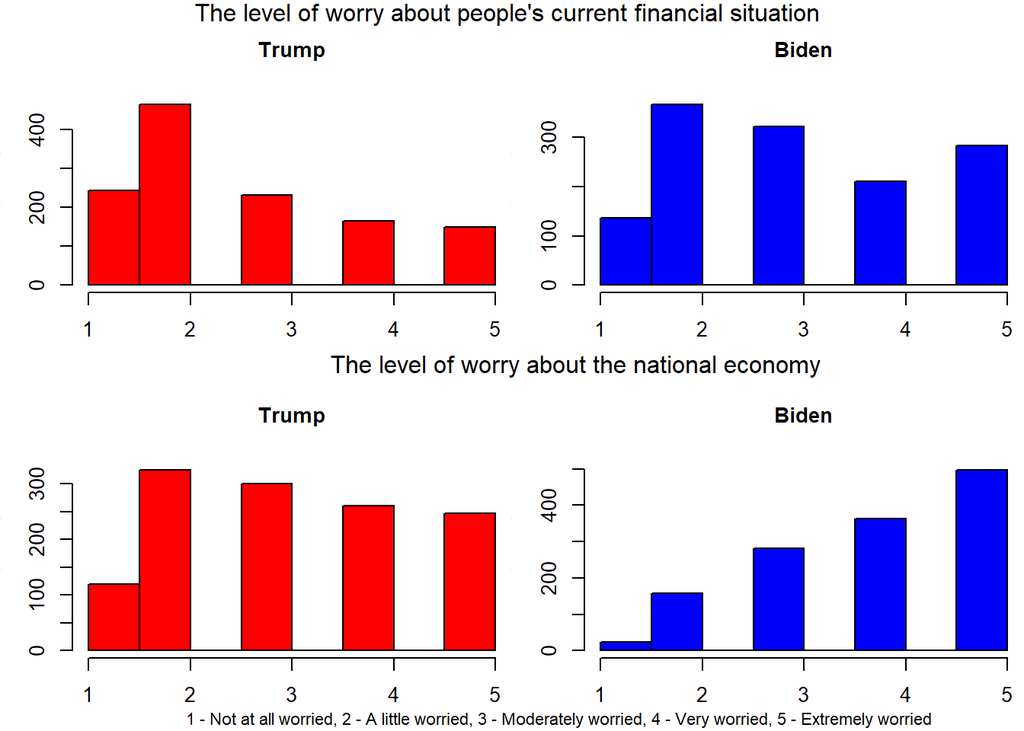

```r
par(mfrow=c(2,2),mar=c(3,3,4,0))
hist(trump20$finworry[trump20$finworry<=5],xlab = 'Response',main = 'Trump',cex.main=1,col="red")
hist(biden20$finworry[biden20$finworry<=5],xlab = 'Response',main = 'Biden',cex.main=1,col="blue")

hist(trump20$confecon[trump20$confecon<=5],xlab = 'Response',main = 'Trump',cex.main=1,col="red")
hist(biden20$confecon[biden20$confecon<=5],xlab = 'Response',main = 'Biden',cex.main=1,col="blue")

mtext("1 - Not at all worried, 2 - A little worried, 3 - Moderately worried, 4 - Very worried, 5 - Extremely worried", cex = .7,line = -11, adj=1.3)
mtext("The level of worry about people's current financial situation", cex = 1,line=+18,adj=2.1)
mtext("The level of worry about the national economy", cex = 1,line=+3.5,adj=5)
```

In addition, Biden’s supporters are concerned about both their current financial situation and the national economy, while Trump’s supporters are less concerned about their current financial situation but more concerned about the national economy.

Maybe it is because Trump’s supporters are richer than Biden’s. Let’s take a look at their income levels.

### Income level & income differences

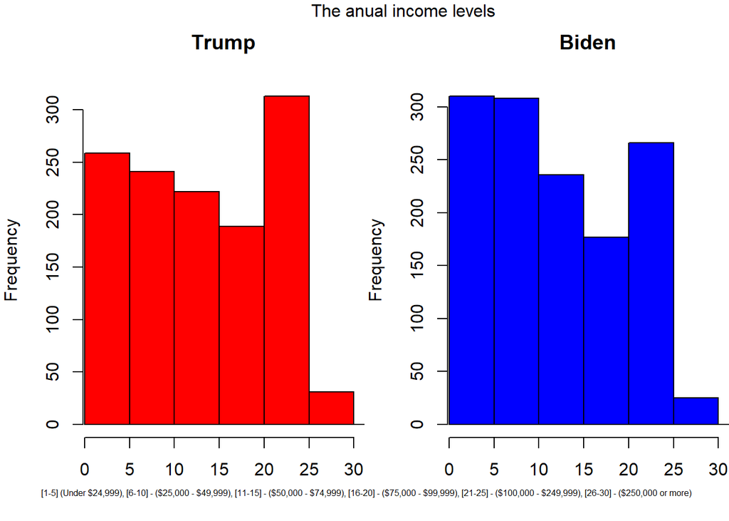

```r
par(mfrow=c(1,2),mar=c(4,4,4,0))
hist(ifelse(trump20$inc_anes==66, ifelse(trump20$inc_cps==66,trump20$inc_cpsmod,trump20$inc_cps),trump20$inc_anes),xlim=c(1,30),breaks=25,xlab='',main='Trump',col="red")
hist(ifelse(biden20$inc_anes==66, ifelse(biden20$inc_cps==66,biden20$inc_cpsmod,biden20$inc_cps),biden20$inc_anes),xlim=c(1,30),breaks=25,xlab='',main='Biden',col="blue")
mtext("The anual income levels", cex = 1,line=+3,adj=-1.4)
mtext("[1-5] (Under $24,999), [6-10] - ($25,000 - $49,999), [11-15] - ($50,000 - $74,999), [16-20] - ($75,000 - $99,999), [21-25] - ($100,000 - $249,999), [26-30] - ($250,000 or more)",cex=0.5,line = -20,adj=+1.1)
```

From the plot, we can tell that there are more low-income people are supporting Biden. This supports the previous argument.

What worth mentioning is that from analyzing the data, we find that Biden’s supporters agree more on that the government should pass laws and regulations to reduce the income differences between rich people and poor people. The argument is also supported by the previous argument that Trump’s supporters are richer than Biden’s supporters.

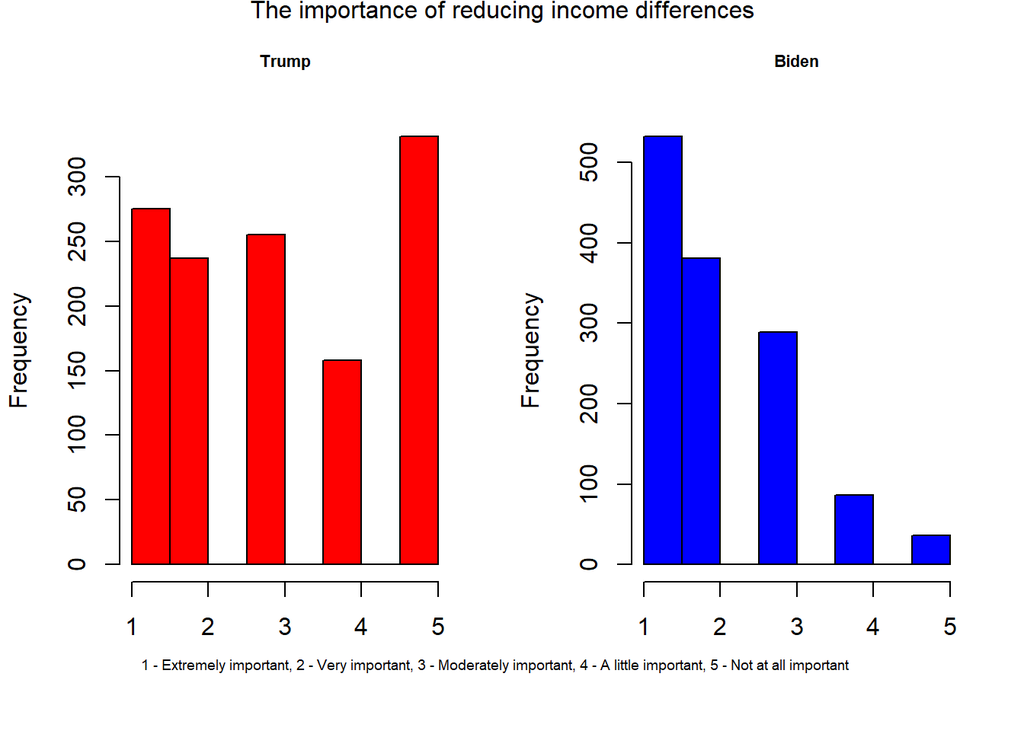

```r
par(mfrow=c(1,2))
hist(trump20$richpoor2[trump20$richpoor2<=5],xlab='',main='Trump',col="red",cex.main=.7)
hist(biden20$richpoor2[biden20$richpoor2<=5],xlab='',main='Biden',col="Blue",cex.main=.7)

mtext("The importance of reducing income differences", cex = 1,line=+3.3,adj=+2.2)
mtext("1 - Extremely important, 2 - Very important, 3 - Moderately important, 4 - A little important, 5 - Not at all important",cex=.6,line = -19,adj=+1.3)
```

Besides the findings of the difference of income levels and the difference of the attitude towards income differences, we find more interesting aspects that can explain why Biden’s supporters agree more on Trump’s economic policy than other fields.

### Free market or strong government

In the survey, people are asked to share their opinions about which one do they prefer, let the free market handle the economic problems or let the strong government handle them.

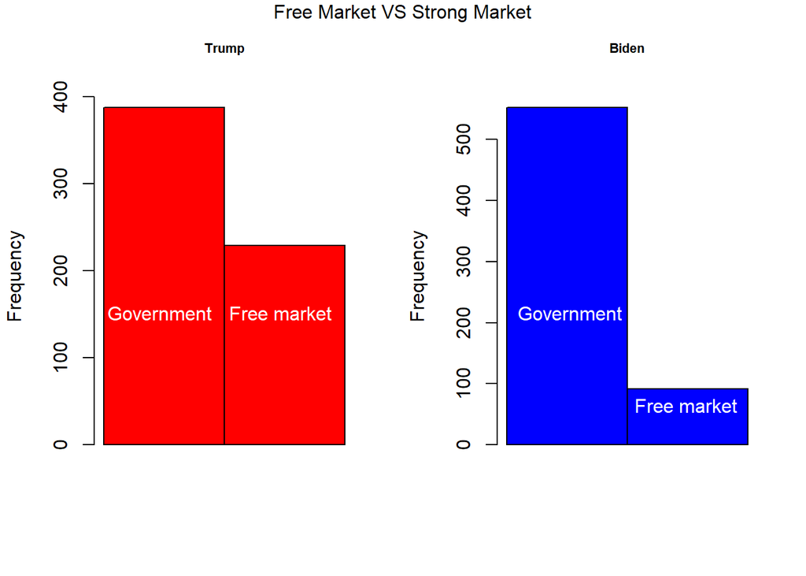

```r
par(mfrow=c(1,2))
hist(trump20$freemkt1a[trump20$freemkt1a<=2],breaks=2,main='Trump',col="red",cex.main=.7,xlab='',xaxt='n',)
hist(biden20$freemkt1a[biden20$freemkt1a<=2],breaks=2,main='Biden',col="Blue",cex.main=.7,xlab='',xaxt='n')
mtext("Free Market VS Strong Market", outer=TRUE,cex = 1,line=-1)
mtext("Government",cex=1,line = -10,adj=-2.5,col="white")
mtext("Free market",cex=1,line = -10,adj=-1.7,col="white")
mtext("Government",cex=1,line = -10,adj=+.13,col="white")
mtext("Free market",cex=1,line = -14,adj=+.87,col="white")
```

According to the plot, Biden’s supporters prefer more about a strong government. And it’s a fact that during the last four years, Trump took many actions on the economy. So, it supports the previous argument that Biden’s supporters agree more on Trump’s economic policy than other fields.

## Health Care & COVID-19

In the previous part of the analysis, we find that some of Trump’s supporters dislike his policy in **Health Care & COVID-19**.

Let’s take a look at what do Americans think about Health Care and COVID-19.

In the survey, we find that Trump’s supporters are not as worried about their chances of getting COVID-19 as Biden’s supporters. See the following plot.

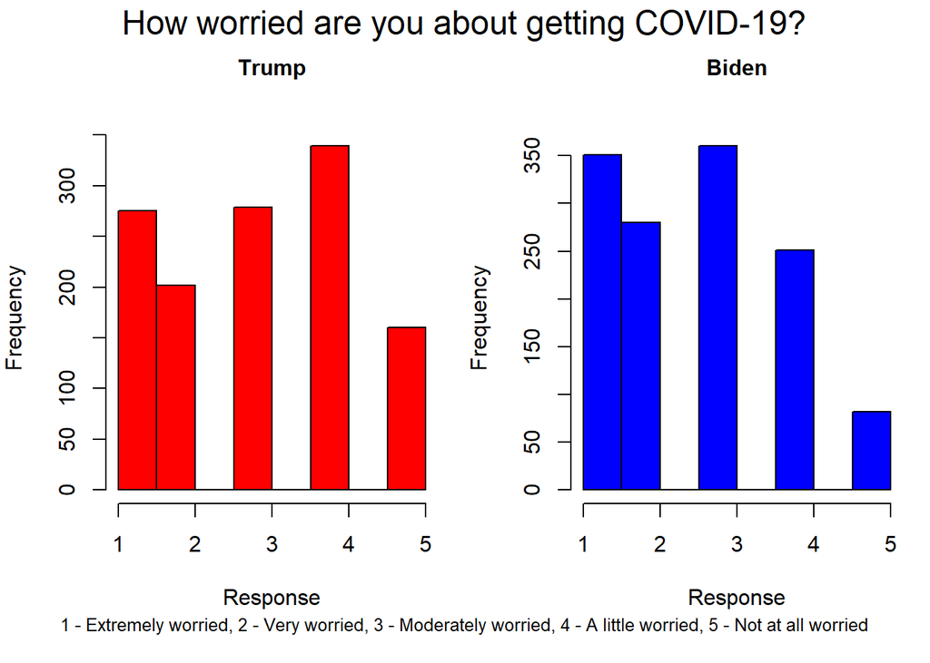

```r
par(mfrow=c(1,2),mar=c(6,4,5,1))
hist(trump20$covid1[trump20$covid1<=5],xlab = 'Response',main = 'Trump',cex.main=1,col="red")
hist(biden20$covid1[biden20$covid1<=5],xlab = 'Response',main = 'Biden',cex.main=1,col="blue")
mtext("How worried are you about getting COVID-19?",outer=TRUE, cex = 1.5,line=-1.5)
mtext("1 - Extremely worried, 2 - Very worried, 3 - Moderately worried, 4 - A little worried, 5 - Not at all worried", outer=TRUE,cex = .8,line=-24)
```

However, it shows a big difference between Trump’s supporters and Biden’s supporters about their attitude towards whether the government should pay for the health care of all Americans.

The reason behind this may be their difference in income.

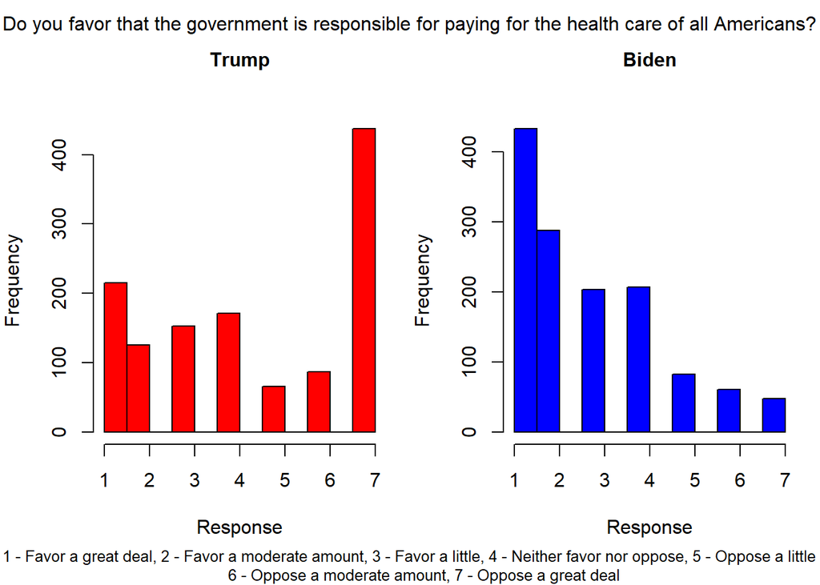

```r
par(mfrow=c(1,2),mar=c(6,4,5,1))
hist(trump20$hlthcare1[trump20$hlthcare1<=7],xlab = 'Response',main = 'Trump',cex.main=1,col="red",breaks = 10)
hist(biden20$hlthcare1[biden20$hlthcare1<=7],xlab = 'Response',main = 'Biden',cex.main=1,col="blue",breaks = 10)
mtext("Do you favor that the government is responsible for paying for the health care of all Americans?",outer=TRUE, cex = 1,line=-1.5)
mtext("1 - Favor a great deal, 2 - Favor a moderate amount, 3 - Favor a little, 4 - Neither favor nor oppose, 5 - Oppose a little
       6 - Oppose a moderate amount, 7 - Oppose a great deal", outer=TRUE,cex = .8,line=-25)
```

# Conclusion

From the survey, we learn about some interesting findings.